# Prediction of EW Volume BV’s using LGEP: SNPs 012

Adam Festa

6/10/2018

## 0.1 Load data

- First, load the –012 output produced during the SNP filtering.
- File loaded below has no missing snps, MAF > .05, and are of at least Q30.
- Additionally, the data frame contains rownames for bioloigcal samples and colnames as snp name/position

```r
load("/mnt/bio.012.df.RData")
```

- Now load the phenotypes

```r
## Load phenotype data ####
#load("~/Documents/Grad_Projects/Breeding-Value-Prediction/disk6directory/resources/expt.dat.720.RData")
load("/mnt/Breeding-Value-Prediction/disk6directory/resources/expt.dat.720.RData")
expt.dat.720$animal_id <- as.character(expt.dat.720$animal_id)
expt.dat.720$fam_id <- as.character(expt.dat.720$fam_id)
expt.dat.720$batch <- as.character(expt.dat.720$batch)

# Create bio phenos from individuals with no missing Volume and who have unique, fam*animal*batch*vol combo
bio.phenos <- unique(expt.dat.720[which(!is.na(expt.dat.720$Volume) ==T),c("fam_id","animal_id","batch","Volume")])
```

- The bio phenos animal id and 012 matrix have the same style names but are not in the same order. Match 012 genos to phenotype data

```r
# Index the snp data frame to only include individuals which have phenotypes
keep.index <-  which(rownames(bio.012.df) %in% bio.phenos$animal_id)

# Keep only those rows
bio.012.df <- bio.012.df[keep.index,]

bio.phenos <- bio.phenos[which(bio.phenos$animal_id %in% rownames(bio.012.df)),]
identical(bio.phenos$animal_id[match(rownames(bio.012.df),bio.phenos$animal_id)],rownames(bio.012.df))
```

```
## [1] TRUE
```

```r
bio.phenos <- bio.phenos[match(rownames(bio.012.df),bio.phenos$animal_id),]
rownames(bio.phenos) <- bio.phenos$animal_id
rm(keep.index)
```

## 0.2 Generate family-level data

- Generate family phenos

```r
fam.phenos <- unique(bio.phenos[,c("fam_id","Volume")])
rownames(fam.phenos) <- fam.phenos$fam_id
u.fams <- unique(fam.phenos$fam_id)
```

- The family mean SNP matrix was generated once using the FULL bio 012 matrix and then saved. It’s loaded here

```r
load("/mnt/fam.012.df.RData")
```

## 0.3 Create test/train matricies

- Some of the filtering methods will use phenotypes, while others will not, but we can go ahead and split the LGEP and EW into train/test for those filtering methods that do use phenos

```r
# Identify crossover families between batches
crossover.fams <- unique(bio.phenos[,c("fam_id","Volume","batch")])
crossover.fams <- names(which(table(crossover.fams$fam_id) ==2))

# Subset the unique list of families that are in the LGEP or EW
ew.fams <- unique(bio.phenos$fam_id[which(bio.phenos$batch == "EW")])
lgep.fams <- unique(bio.phenos$fam_id[which(bio.phenos$batch == "LGEP")])

# Remove LGEP families from the EW families (i.e. remove crossover families)
ew.fams <- ew.fams[-which(ew.fams %in% crossover.fams)]

# Create a training set from the biological replicates using the lgep and ew families
train.p.bio <- bio.phenos$Volume[which(bio.phenos$fam_id %in% lgep.fams)]
train.dat.bio <- bio.012.df[which(bio.phenos$fam_id %in% lgep.fams),]
#colnames(train_d.bio) <- 1:ncol(train.dat)
```

- The object `train.dat.bio` now contains the LGEP 012 output and the `bio.012.df` object contains the full 189 biological replicates.

## 0.4 Apply filters

- Apply caret filters including:
  - ANOVA scores: These are generated using phenotypes, so only the LGEP will be used to identify a subset to predict
  - BCV: This may be generated without phenotypes, so the whole dataset will be used.
  - nearzerovar: This may also be used without phenotypes, so the whole dataset will be used.

### 0.4.1 Generate anova scores

- Use caret package to generate anova scores with the LGEP 012 counts and phenos (i.e. `train.dat` & `train.phenos` objects)

```
# Using the biological replicate training set, apply anovaScores to each SNP
LGEP.anova.scores <- unlist(mclapply(1:ncol(train.dat.bio), function(each.col){
  anovaScores(x = train.dat.bio[,each.col],y = train.p.bio)},mc.cores=32))
save(LGEP.anova.scores,file="/mnt/LGEP.anova.scores.RData",compress = T)
```

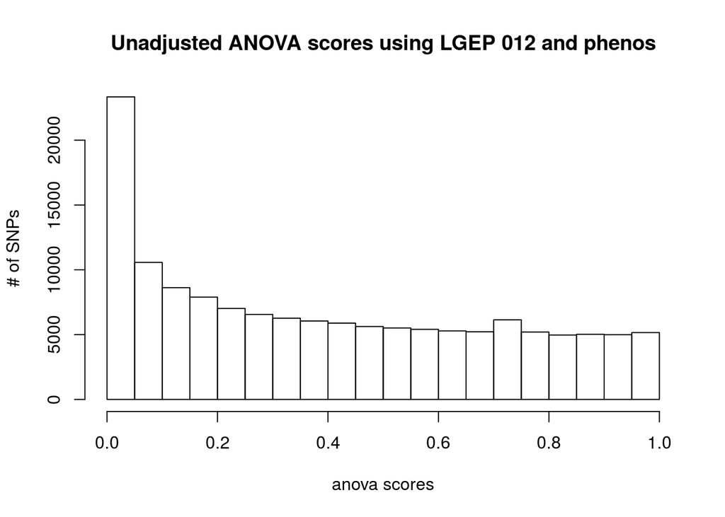

```r
load("/mnt/LGEP.anova.scores.RData")
# Generate a histogram of these anova scores
hist(LGEP.anova.scores, main="Unadjusted ANOVA scores using LGEP 012 and phenos",xlab ="anova scores",ylab="# of SNPs")
```

```r
# How many of anova scores are less than .05 (unadjusted)
length(which(LGEP.anova.scores < .05))
```

```
## [1] 23344
```

```r
# How many of anova scores are less than .05 (adjusted)
length(which(p.adjust(LGEP.anova.scores) < .05))
```

```
## [1] 88
```

### 0.4.2 Filter BCV

- Here we will use the whole 012 data set to identify SNPs who have high BCV relative to all samples (BCV= sd/mean)

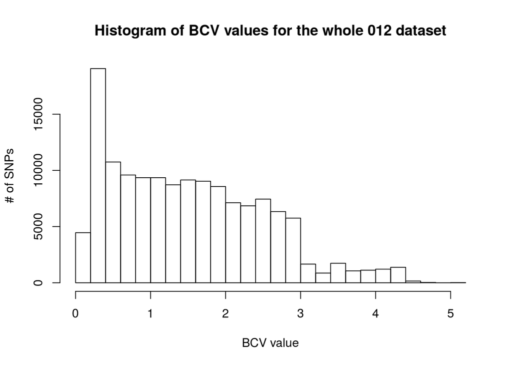

```r
# Estimate the variance, sd, mean, and bcv for each SNP
var.snps <- apply(bio.012.df,2,var)
sd.snps <- apply(bio.012.df,2,sd)
mean.snps <- apply(bio.012.df,2,mean)
bcv.snps <- sd.snps/mean.snps

# Take a look at the distribution of bcv values
hist(bcv.snps,main = "Histogram of BCV values for the whole 012 dataset",xlab="BCV value",ylab="# of SNPs")
```

```r
length(which(bcv.snps > 3))
```

```
## [1] 9219
```

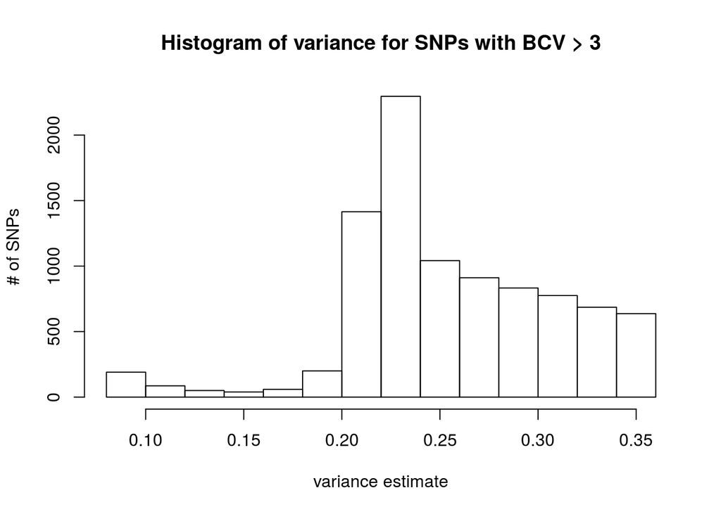

```r
# Look at the histogram of variance using only those SNPs with bcv > 3
hist(var.snps[which(bcv.snps > 3)],main="Histogram of variance for SNPs with BCV > 3",xlab = "variance estimate",ylab = "# of SNPs")
```

```r
length(which(var.snps[which(bcv.snps > 3)] < .2))
```

```
## [1] 624
```

```r
interesting.bcv.snps <- which(var.snps[which(bcv.snps > 3)] < .2)
```

- A total of 9,219 SNPs have BCV values greater than 3.
- There is an interesting set of 624 SNPs which have a BCV greater than 3 but variance less than 0.2

### 0.4.3 Filter the nearzerovar

```r
# This near zero var will check for things which have less than 10 or less unique values and 95/5 most common/least common (19:1 ratio)
check.vars <- nearZeroVar(x = bio.012.df,allowParallel = T)

# How many did not meet these thresholds?
length(check.vars)
```

```
## [1] 6624
```

```r
## 6,624 SNPs did not meet threshold
```

- A total of 6624 SNPs did not meet this threshold, let’s take a look at their BCV values

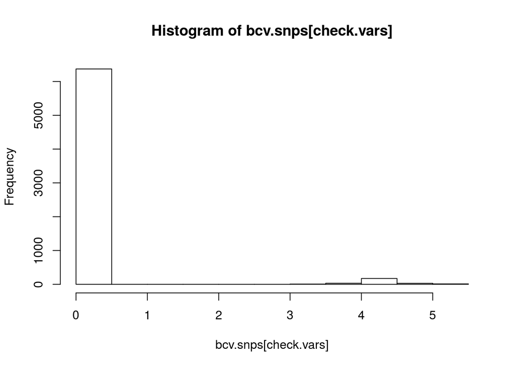

```r
hist(bcv.snps[check.vars])
```

- There is an odd set which have > 3 BCV. Let’s subset those out too.

```r
near.zero.bcv3.snps <- check.vars[which(bcv.snps[check.vars] > 3)]
length(near.zero.bcv3.snps)
```

```
## [1] 253
```

- A total of 253 SNPs were identified as being removed by the nearzerovar BUT they had BCV > 3. We will keep those for further inspection.
- Do these 253 SNPs show up as significant in the p-adjusted anova scores on the full data?

```r
summary(p.adjust(LGEP.anova.scores)[check.vars])
```

```
##    Min. 1st Qu.  Median    Mean 3rd Qu.    Max.
##       1       1       1       1       1       1
```

- No, none of these 253 were identified as being associated with the LGEP
- How do the variance of these SNPs look?

```r
summary(var.snps[near.zero.bcv3.snps])
```

```
##    Min. 1st Qu.  Median    Mean 3rd Qu.    Max.
##  0.1434  0.1824  0.1824  0.1796  0.1824  0.2150
```

- The SNP variance’s are all pretty small. We will still keep this set and use during prediction.

## 0.5 Predictions

- Establish the training and testing

```r
# Split test and train set by batch
ew.fams <- unique(bio.phenos$fam_id[which(bio.phenos$batch == "EW")])
lgep.fams <- unique(bio.phenos$fam_id[which(bio.phenos$batch == "LGEP")])

# Remove crossover fams from test set
ew.fams <- ew.fams[-which(ew.fams %in% crossover.fams)]
```

### 0.5.1 All transcripts: BIO Reps

- Bio-reps: NO SCALING

```r
cor.mat <- cor(t(bio.012.df))
rownames(cor.mat) <- 1:nrow(bio.phenos); colnames(cor.mat) <- 1:nrow(bio.phenos)
rownames(bio.phenos) <- 1:nrow(bio.phenos)

TRAIN.fams <- which(bio.phenos$fam_id %in% lgep.fams)
TEST.fams <- which(bio.phenos$fam_id %in% ew.fams)

predictions <- okriging(idtest = TEST.fams,idtrain = TRAIN.fams,
                        corlist = list(cor.mat),H2vec = c(.99),
                        pheno = bio.phenos,phenoname = "Volume")

cor(predictions$Ypred,predictions$Ytest)
```

```
## [1] 0.7318431
```

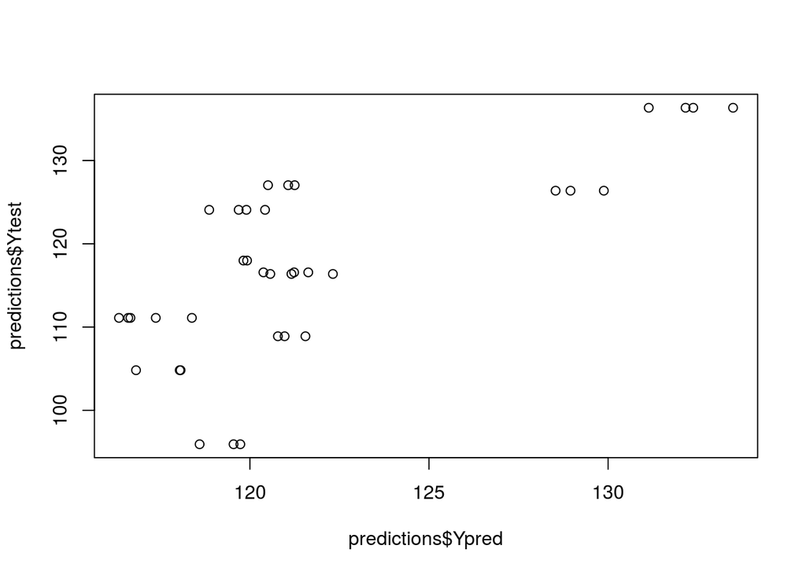

```r
plot(predictions$Ypred,predictions$Ytest)
```

### 0.5.2 All transcripts: FAMILY-level

- Fam reps: NO SCALING/CENTERING

```r
cor.mat <- cor(t(fam.012.df))
rownames(cor.mat) <- rownames(fam.phenos); colnames(cor.mat) <- rownames(fam.phenos)
TRAIN.fams <- lgep.fams
TEST.fams <- ew.fams

predictions <- okriging(idtest = TEST.fams,idtrain = TRAIN.fams,corlist = list(cor.mat),
                        H2vec = c(.99),pheno = fam.phenos,phenoname = "Volume")

cor(predictions$Ypred,predictions$Ytest)
```

```
## [1] 0.7210332
```

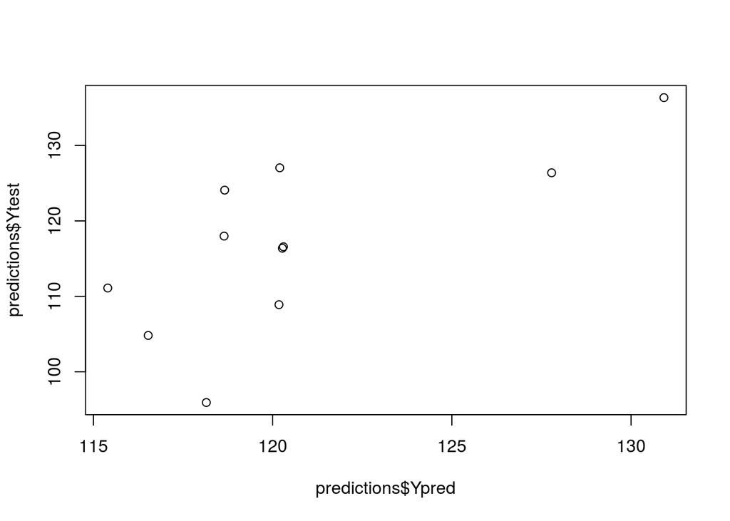

```r
plot(predictions$Ypred,predictions$Ytest)
```

### 0.5.3 BCV transcripts: FAMILY-level

- BCV > 3 & VAR < .2

```r
cor.mat <- cor(t(fam.012.df[,which(bcv.snps > 3 & var.snps < .2)]))
rownames(cor.mat) <- rownames(fam.phenos); colnames(cor.mat) <- rownames(fam.phenos)
TRAIN.fams <- lgep.fams
TEST.fams <- ew.fams

predictions <- okriging(idtest = TEST.fams,idtrain = TRAIN.fams,corlist = list(cor.mat),
                        H2vec = c(.99),pheno = fam.phenos,phenoname = "Volume")

cor(predictions$Ypred,predictions$Ytest)
```

```
## [1] 0.4659515
```

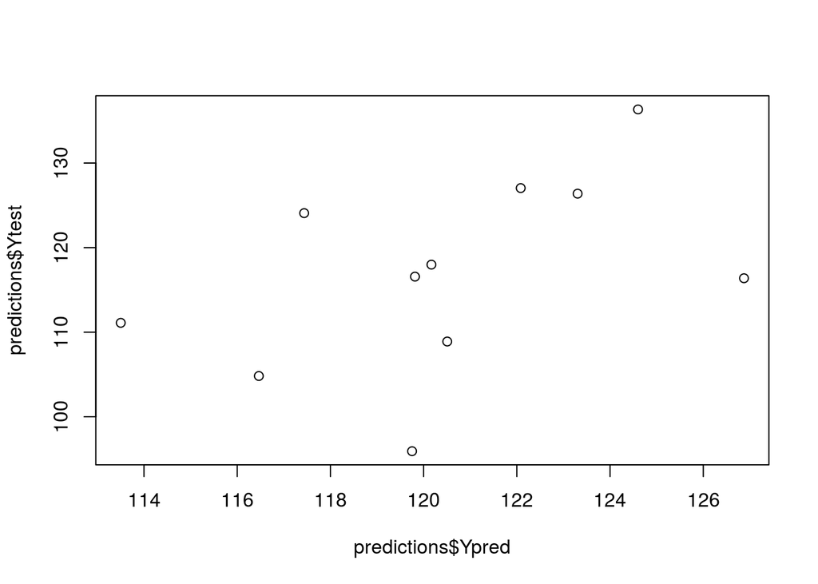

```r
plot(predictions$Ypred,predictions$Ytest)
```

- BCV > 3 & VAR > .2

```r
cor.mat <- cor(t(fam.012.df[,which(bcv.snps > 3 & var.snps > .2)]))
rownames(cor.mat) <- rownames(fam.phenos); colnames(cor.mat) <- rownames(fam.phenos)
TRAIN.fams <- lgep.fams
TEST.fams <- ew.fams

predictions <- okriging(idtest = TEST.fams,idtrain = TRAIN.fams,corlist = list(cor.mat),
                        H2vec = c(.99),pheno = fam.phenos,phenoname = "Volume")

cor(predictions$Ypred,predictions$Ytest)
```

```
## [1] 0.7420994
```

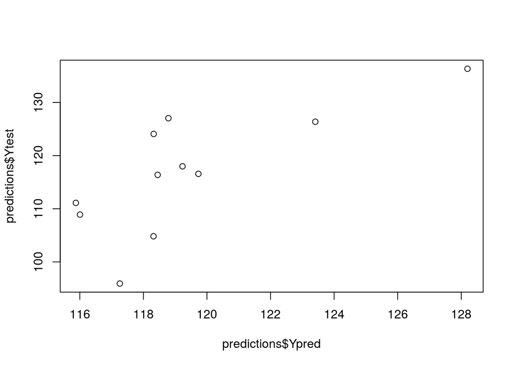

```r
plot(predictions$Ypred,predictions$Ytest)
```

### 0.5.4 OK: Adjusted anova vals

- Try omickriging on different subset of p-val thresholds

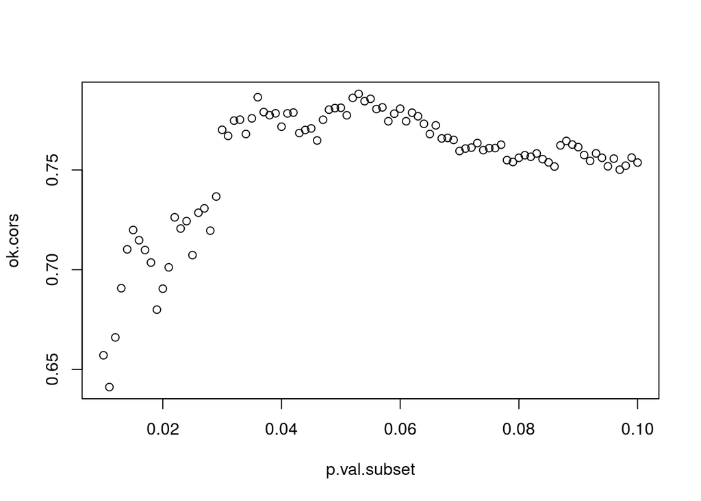

```r
LGEP.anova.scores.adjust <- p.adjust(LGEP.anova.scores,method = "fdr")
p.val.subset <- seq(to = .1,from = .01,by = .001)

ok.cors <- unlist(mclapply(1:length(p.val.subset),function(each.p){
cor.mat <- cor(t(fam.012.df[,which(LGEP.anova.scores.adjust < p.val.subset[[each.p]])]))
rownames(cor.mat) <- rownames(fam.phenos); colnames(cor.mat) <- rownames(fam.phenos)

TRAIN.fams <- lgep.fams
TEST.fams <- ew.fams
predictions <- okriging(idtest = TEST.fams,idtrain = TRAIN.fams,corlist = list(cor.mat),
                        H2vec = c(.99),pheno = fam.phenos,phenoname = "Volume")

cor(predictions[,2],predictions[,3])
},mc.cores=34))

plot(p.val.subset,ok.cors)
```

### 0.5.5 GLMNET: all data

- Use GLMNET on the whol family snp data frame

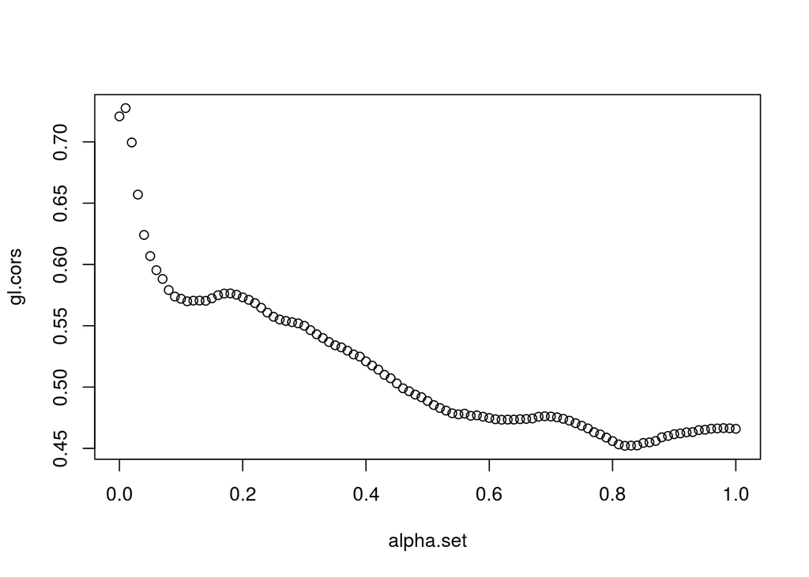

```r
TEST.fams <- which(fam.phenos$fam_id %in% ew.fams)
TRAIN.fams <- which(fam.phenos$fam_id %in% lgep.fams)

alpha.set <- seq(0,1,.01)
gl.cors <- unlist(mclapply(1:length(alpha.set),function(each){
gl.mod <- glmnet(x = fam.012.df[-TEST.fams,],
                  y = fam.phenos$Volume[-TEST.fams],alpha = alpha.set[each],standardize = F)
predictions <- predict.glmnet(gl.mod,newx = fam.012.df[TEST.fams,])
cor(predictions[,ncol(predictions)],fam.phenos$Volume[TEST.fams])
},mc.cores=34))
plot(alpha.set,gl.cors)
```

```
test.fams <- which(fam.phenos$fam_id %in% ew.fams)
train.fams <- which(fam.phenos$fam_id %in% lgep.fams)

TRAIN.fams <- lgep.fams
TEST.fams <- ew.fams

alpha.set <- seq(0,1,.01); cor.weight=.99
gl.cors <- c()
for(each in 1:length(alpha.set)){
gl.mod <- glmnet(x = fam.012.df[-test.fams,],
                  y = fam.phenos$Volume[-test.fams],alpha = alpha.set[each],standardize = F)

 out <- gl.mod$beta
 select <- which(out[,ncol(out)] > 0)

 cor.mat <- cor(t(fam.012.df[,select]))
rownames(cor.mat) <- rownames(fam.phenos); colnames(cor.mat) <- rownames(fam.phenos)
predictions <- okriging(idtest = TEST.fams,idtrain = TRAIN.fams,corlist = list(cor.mat),H2vec = c(cor.weight),pheno = fam.phenos,phenoname = "Volume")
predictions[,2:3] <- predictions[,2:3] - mean(fam.phenos$Volume[which(fam.phenos$fam_id %in% lgep.fams)])
gl.cors <- c(gl.cors,cor(predictions$Ypred,predictions$Ytest))}

plot(alpha.set,gl.cors)
```

### 0.5.6 GLMNET: adjusted anova values

- Do the same for the adjusted p-values with the expectation the we will also test 3 different alpha’s: 1,0,.5

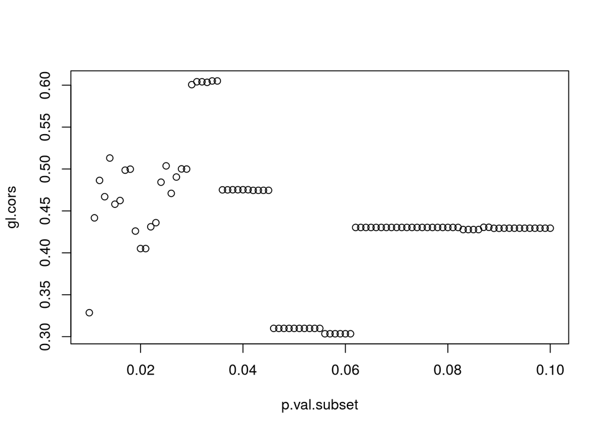

```r
LGEP.anova.scores.adjust <- p.adjust(LGEP.anova.scores,method = "fdr")
p.val.subset <- seq(to = .1,from = .01,by = .001)
# ALPHA = 1 Try on adjusted pvals ####
gl.cors <- unlist(mclapply(1:length(p.val.subset),function(each){
gl.mod <- glmnet(x = fam.012.df[-TEST.fams,which(LGEP.anova.scores.adjust <= p.val.subset[each])],
                  y = fam.phenos$Volume[-TEST.fams],alpha = 1,standardize = F)
predictions <- predict.glmnet(gl.mod,newx = fam.012.df[TEST.fams,which(LGEP.anova.scores.adjust <= p.val.subset[each])])
cor(predictions[,ncol(predictions)],fam.phenos$Volume[TEST.fams])
},mc.cores=34))
plot(p.val.subset,gl.cors)
```

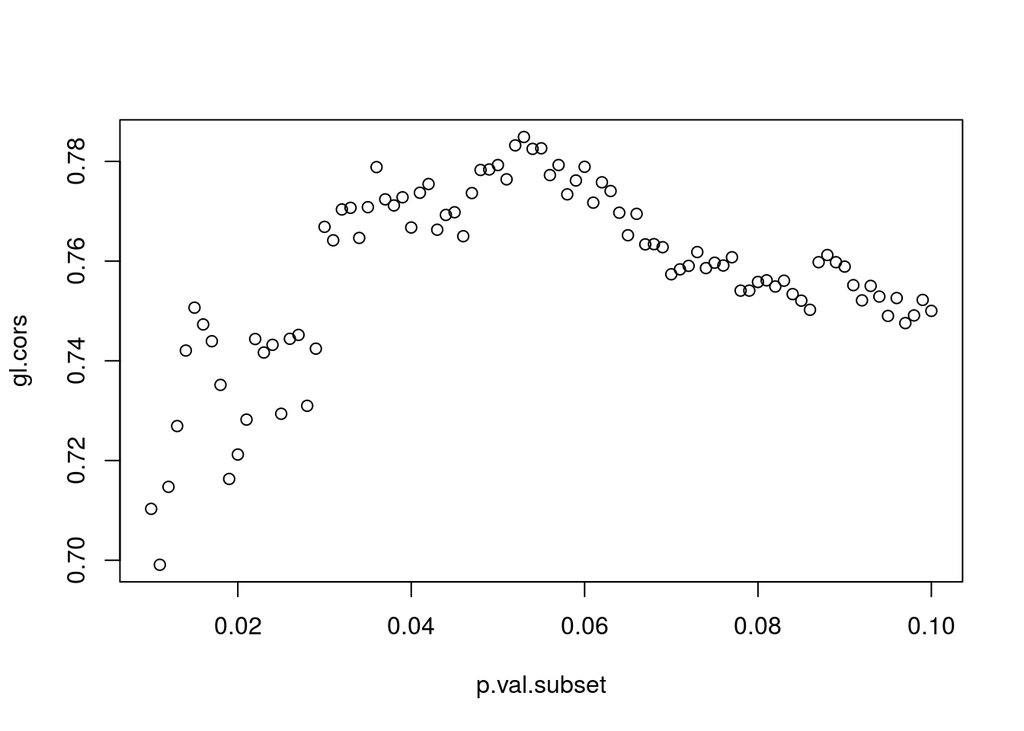

```r
# ALPHA = 0 ####
gl.cors <- unlist(mclapply(1:length(p.val.subset),function(each){
gl.mod <- glmnet(x = fam.012.df[-TEST.fams,which(LGEP.anova.scores.adjust <= p.val.subset[each])],
                  y = fam.phenos$Volume[-TEST.fams],alpha =0,standardize = F)
predictions <- predict.glmnet(gl.mod,newx = fam.012.df[TEST.fams,which(LGEP.anova.scores.adjust <= p.val.subset[each])])
cor(predictions[,ncol(predictions)],fam.phenos$Volume[TEST.fams])
},mc.cores=34))
plot(p.val.subset,gl.cors)
```

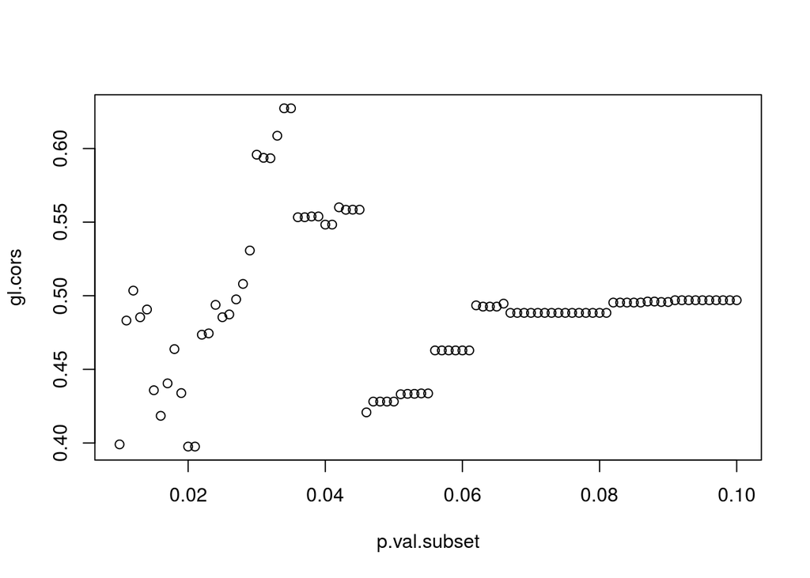

```r
# ALPHA = 0.5 ####
gl.cors <- unlist(mclapply(1:length(p.val.subset),function(each){
gl.mod <- glmnet(x = fam.012.df[-TEST.fams,which(LGEP.anova.scores.adjust <= p.val.subset[each])],
                  y = fam.phenos$Volume[-TEST.fams],alpha = .5,standardize = F)
predictions <- predict.glmnet(gl.mod,newx = fam.012.df[TEST.fams,which(LGEP.anova.scores.adjust <= p.val.subset[each])])
cor(predictions[,ncol(predictions)],fam.phenos$Volume[TEST.fams])
},mc.cores=34))
plot(p.val.subset,gl.cors)
```

## 0.6 Top r2 which is around .05 pval

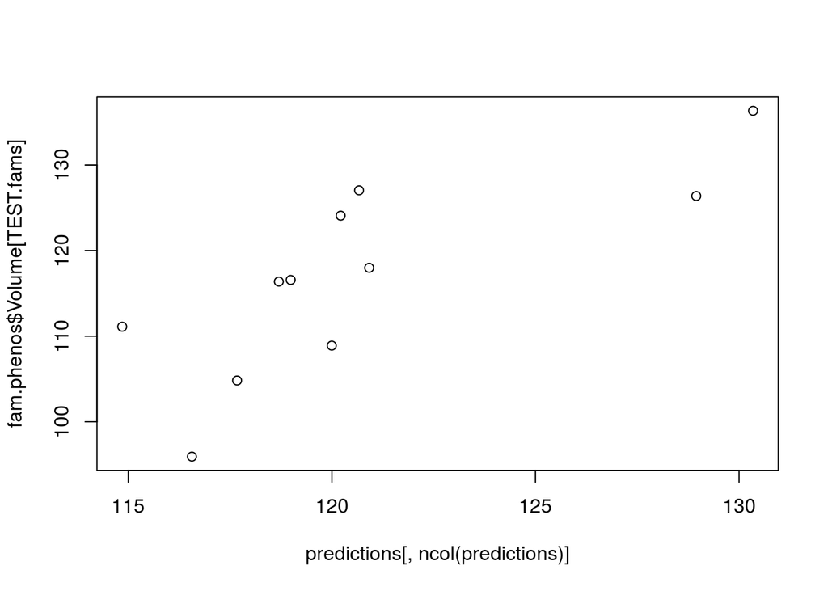

```r
TEST.fams <- which(fam.phenos$fam_id %in% ew.fams)
TRAIN.fams <- which(fam.phenos$fam_id %in% lgep.fams)
gl.mod <- glmnet(x = fam.012.df[-TEST.fams,which(LGEP.anova.scores.adjust <= .05)],
                  y = fam.phenos$Volume[-TEST.fams],alpha =0,standardize = F)
predictions <- predict.glmnet(gl.mod,newx = fam.012.df[TEST.fams,which(LGEP.anova.scores.adjust <= .05)])
plot(predictions[,ncol(predictions)],fam.phenos$Volume[TEST.fams])
```

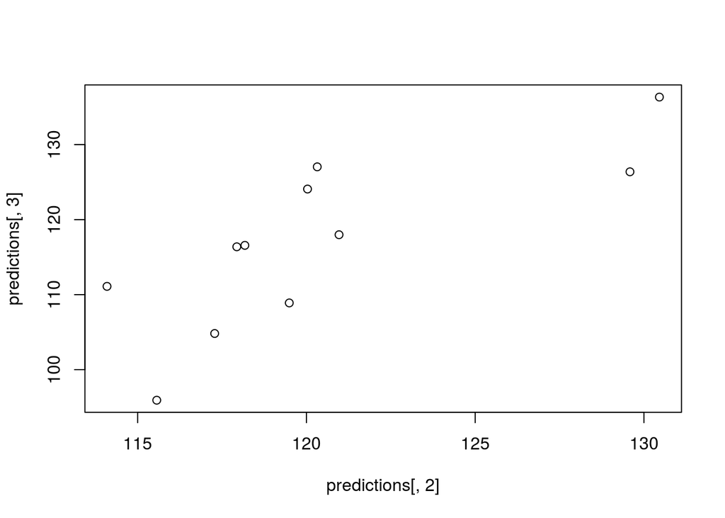

```r
cor.mat <- cor(t(fam.012.df[,which(LGEP.anova.scores.adjust < .05)]))
rownames(cor.mat) <- rownames(fam.phenos); colnames(cor.mat) <- rownames(fam.phenos)

TRAIN.fams <- lgep.fams
TEST.fams <- ew.fams
predictions <- okriging(idtest = TEST.fams,idtrain = TRAIN.fams,corlist = list(cor.mat),
                        H2vec = c(.99),pheno = fam.phenos,phenoname = "Volume")

plot(predictions[,2],predictions[,3])
```

## 0.7 Save image

```r
save.image(file="/mnt/LGEP_EW_pred.snps.RData",compress=T)
```